# Problem Set 4

Author

Meredith Grimshaw

Published

November 20, 2026

## **GitHub Repository:** https://github.com/mgrimshaw449/ec422_ps4_grimshaw.

## 1. ARIMA vs. ETS

### Seasonal Patterns in Liquor Sales

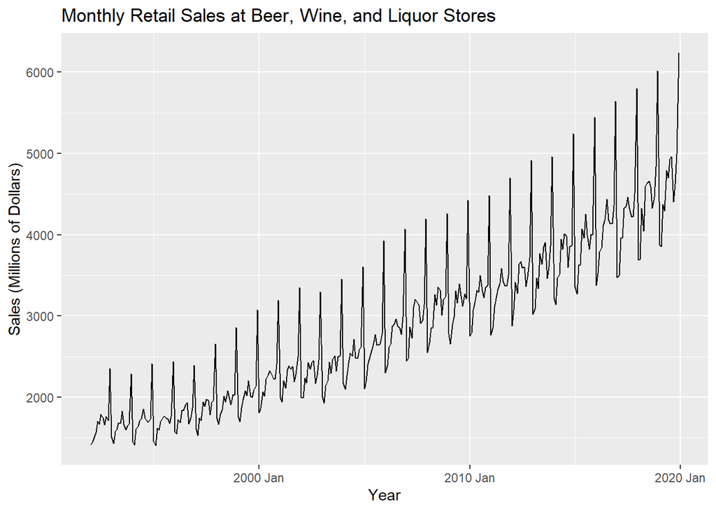

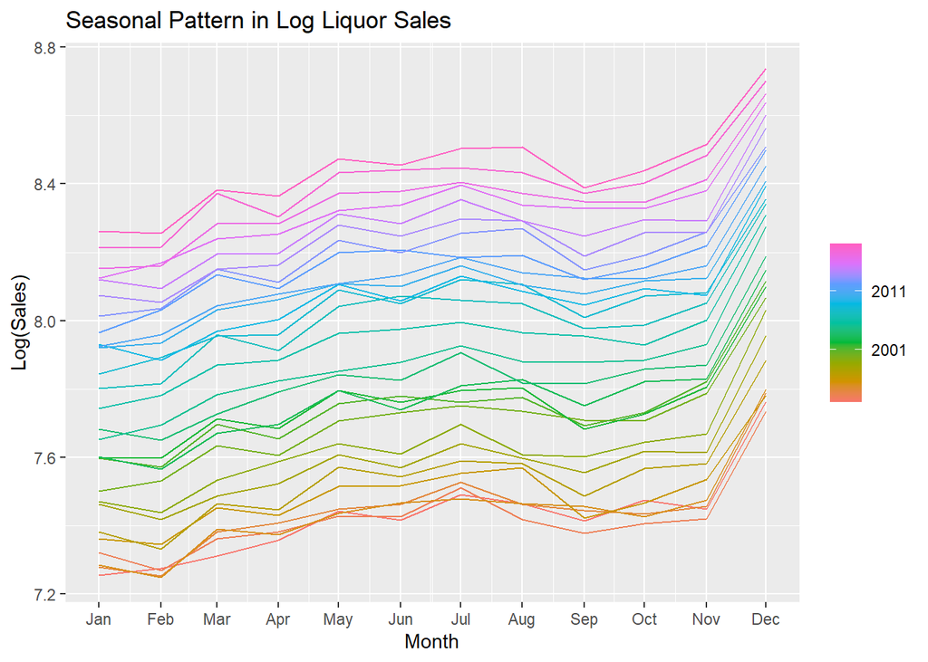

Monthly liquor sales exhibit a clear seasonal pattern, with sales peaking in December and generally reaching their lowest levels in January and February. A smaller increase also occurs during the summer months. Because seasonal fluctuations become larger as overall sales increase, taking logarithms may help stabilize the seasonal variation.

### Model Selection

```
Series: sales
Model: ARIMA(1,0,2)(2,1,1)[12] w/ drift
Transformation: log(sales)

Coefficients:
         ar1      ma1     ma2    sar1     sar2     sma1  constant
      0.8948  -0.7374  0.2477  0.3679  -0.2334  -0.8845    0.0036
s.e.  0.0355   0.0697  0.0623  0.0668   0.0665   0.0468    0.0001

sigma^2 estimated as 0.0005469:  log likelihood=752.43
AIC=-1488.85   AICc=-1488.4   BIC=-1458.61
```

```
Series: sales
Model: ETS(A,A,A)
Transformation: log(sales)
  Smoothing parameters:
    alpha = 0.3296099
    beta  = 0.007560263
    gamma = 0.0001765132

  Initial states:
     l[0]         b[0]      s[0]      s[-1]        s[-2]       s[-3]      s[-4]
 7.412219 0.0007608238 0.3263441 0.03153301 -0.004849389 -0.03530501 0.02512163
      s[-5]      s[-6]      s[-7]       s[-8]      s[-9]     s[-10]     s[-11]
 0.05558624 0.01219515 0.02503206 -0.06088935 -0.0607952 -0.1578065 -0.1561667

  sigma^2:  7e-04

      AIC      AICc       BIC
-489.1517 -487.2272 -424.2608
```

The selected ARIMA model is ARIMA(1,0,2)(2,1,1)[12] with drift. It uses one seasonal difference at lag 12 but no regular differencing, accounting for annual seasonal patterns in monthly sales. The selected ETS model is ETS(A,A,A), which uses additive errors, an additive trend, and additive seasonality.

### Residual Diagnostics

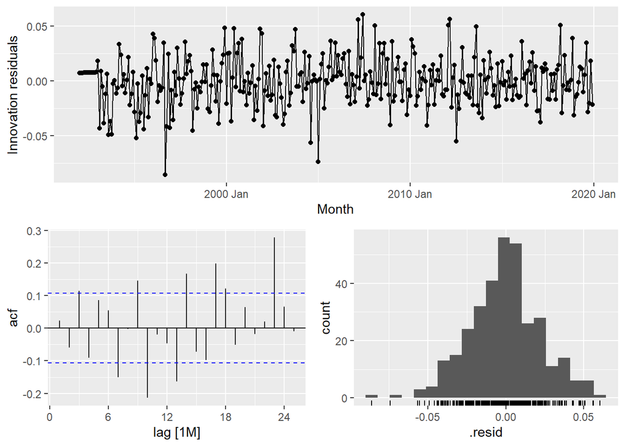

| .model | lb_stat | lb_pvalue |
| --- | --- | --- |
| arima | 120.39 | 0 |

The ARIMA residuals fluctuate around zero, but the ACF plot shows several significant autocorrelations. The Ljung-Box test at lag 24 gives a test statistic of 120 with a p-value below 0.001, so we reject the null hypothesis of no residual autocorrelation. Therefore, the residuals do not resemble white noise, suggesting that the model leaves some patterns unexplained.

### Forecast Accuracy

The expanding-window cross-validation produced 216 one-month-ahead forecasts, from January 2002 through December 2019.

| .model | .type | RMSE | MAE |
| --- | --- | --- | --- |
| arima | Test | 81.43 | 65.65 |
| ets | Test | 94.35 | 72.31 |
| snaive | Test | 161.26 | 136.63 |

ARIMA performed best, with an RMSE of 81.43 and MAE of 65.65, followed by ETS (94.35 and 72.31) and seasonal naive (161.26 and 136.63). Both accuracy measures agree that ARIMA is the most accurate forecasting model.

### Diebold-Mariano Tests and Model Recommendation

```
    Diebold-Mariano Test

data:  liquor_errs$arimaliquor_errs$ets
DM = -2.9062, Forecast horizon = 1, Loss function power = 2, p-value =
0.004042
alternative hypothesis: two.sided
```

```
    Diebold-Mariano Test

data:  liquor_errs$arimaliquor_errs$snaive
DM = -10.755, Forecast horizon = 1, Loss function power = 2, p-value <
2.2e-16
alternative hypothesis: two.sided
```

The Diebold-Mariano tests show that ARIMA forecasts significantly more accurately than both ETS (DM = -2.9062, p = 0.0040) and seasonal naive (DM = -10.755, p < 0.001). Since ARIMA has the lowest RMSE and MAE and its accuracy advantage is statistically significant, I would choose ARIMA to forecast sales for the liquor store chain.

## 2. Forecast Combination

This section evaluates whether combining ARIMA and ETS forecasts improves accuracy compared to using either model individually. The combination uses equal weights for both forecasts.

### Forecast Accuracy

| .model | .type | RMSE | MAE |
| --- | --- | --- | --- |
| arima | Test | 81.43 | 65.65 |
| combo | Test | 85.19 | 66.77 |
| ets | Test | 94.35 | 72.31 |
| snaive | Test | 161.26 | 136.63 |

### Forecast Combination Results

The equal-weight combination produced an RMSE of 85.20 and MAE of 66.80. Although this improved upon ETS alone, it did not outperform ARIMA, which had the lowest RMSE and MAE. Therefore, combining the forecasts did not improve overall accuracy compared to the best individual model.

### Correlation Between Forecast Errors

The correlation between ARIMA and ETS forecast errors was 0.8783, indicating a strong positive relationship. Because the models tend to make similar forecasting errors, combining them provides limited diversification benefits. This helps explain why the equal-weight combination did not outperform ARIMA.

### Model Recommendation

Based on the results, I would select ARIMA rather than the equal-weight combination. ARIMA produced the lowest forecast errors, and combining it with ETS slightly reduced accuracy. The high correlation between forecast errors suggests that the models provide relatively little independent forecasting information.

## 3. VAR vs. BVAR

This section compares traditional Vector Autoregression (VAR) models with Bayesian Vector Autoregression (BVAR) models using different lag lengths and shrinkage parameters. Forecast accuracy is evaluated using RMSE across eight economic variables.

### Forecast Accuracy

| Variable | VAR(1) | VAR(4) | BVAR(4), lambda = 0.3 | BVAR(4), lambda = 0.05 |
| --- | --- | --- | --- | --- |
| gdp | 0.513 | 0.569 | 0.539 | 0.567 |
| cons | 0.460 | 0.527 | 0.486 | 0.495 |
| inv | 2.493 | 2.521 | 2.385 | 2.698 |
| emp | 0.196 | 0.228 | 0.211 | 0.315 |
| infl | 0.208 | 0.207 | 0.197 | 0.330 |
| unrate | 0.199 | 0.215 | 0.203 | 0.216 |
| ffr | 0.390 | 0.497 | 0.414 | 0.358 |
| gs10 | 0.361 | 0.379 | 0.359 | 0.362 |

### Comparing VAR and BVAR Models

The BVAR(4) model with λ = 0.3 generally performs better than the OLS VAR(4), producing lower RMSE values for most variables. Although both models use the same variables and four lags, the BVAR applies Bayesian shrinkage to reduce overfitting and improve forecast accuracy.

### Comparison with VAR(1)

The VAR(1) performs better for several variables, including GDP, consumption, employment, and unemployment. This suggests that a simpler model with fewer lags can outperform more complex models, especially when additional parameters introduce estimation uncertainty.

### Effect of Shrinkage

Reducing λ from 0.3 to 0.05 increases shrinkage toward the prior. Forecast accuracy becomes worse for most variables, although the federal funds rate improves. This suggests that excessive shrinkage can remove useful information from the model.

Selecting the model with the lowest RMSE from this table would also produce an overly optimistic estimate of future forecasting accuracy because the same evaluation data would be used to select and assess the model. A separate test sample would provide a more reliable estimate.

### Diebold-Mariano Tests

| Variable | DM_Statistic | P_Value |
| --- | --- | --- |
| GDP Growth | 2.1366 | 0.0347 |
| Inflation | 1.4529 | 0.1489 |

### Statistical Significance of Forecast Differences

For GDP growth, the Diebold-Mariano test produces a p-value of 0.0347, so we reject the null hypothesis of equal forecast accuracy at the 5% significance level. The BVAR(4) with λ = 0.3 has a lower RMSE than VAR(4), indicating a statistically significant improvement in GDP forecasting accuracy.

For inflation, the p-value is 0.1489, so we fail to reject the null hypothesis of equal forecast accuracy. Although BVAR(4) has a slightly lower RMSE, the difference is not statistically significant.

These results show that improvements in RMSE do not necessarily indicate statistically significant improvements in forecasting performance. This reinforces the importance of evaluating both forecast accuracy and statistical significance when comparing models.

## 4. Factor Model

This section uses the FRED-MD dataset to estimate common economic factors through principal component analysis (PCA). These factors are then used to evaluate whether incorporating information from multiple economic indicators improves forecasting accuracy.

### Data and Transformations

The FRED-MD dataset contains monthly economic indicators with different transformation codes. After applying the transformations and removing series with missing values, the final dataset contains 718 monthly observations and 121 economic series, covering March 1960 through December 2019.

Industrial production (INDPRO) and employment (PAYEMS) use transformation code 5, which calculates the growth rate as 100 times the change in the natural logarithm. CPI (CPIAUCSL) uses code 6, which calculates the change in the monthly inflation rate. The federal funds rate (FEDFUNDS) uses code 2, which takes the first difference.

The federal funds rate is differenced rather than transformed into a growth rate because it is already expressed as an interest rate. Changes in percentage points are more meaningful than percentage growth, particularly when interest rates are near zero.

### Principal Component Analysis

| Principal Component | Variance Explained (%) |
| --- | --- |
| PC1 | 14.98 |
| PC2 | 7.41 |
| PC3 | 7.06 |
| First Three Combined | 29.45 |

The first three principal components explain approximately 29.45% of the total variation across the 121 economic series. The first factor explains 14.98%, the second explains 7.41%, and the third explains 7.06%. This indicates that a small number of common factors capture a meaningful portion of the variation across many economic indicators.

### First Factor from FRED-MD

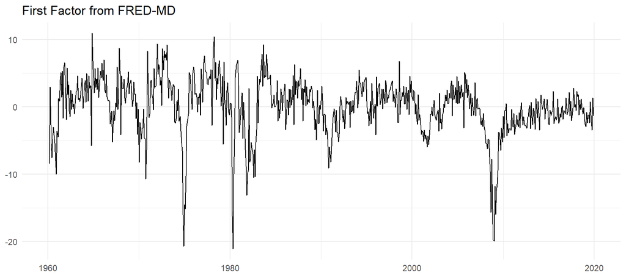

### Interpretation of Economic Factors

The first factor appears to capture overall economic activity, as it is strongly correlated with employment, industrial production, and consumer spending indicators. The plot also shows sharp declines during major economic downturns, supporting its interpretation as a broad measure of economic conditions.

The second factor appears to capture inflation and price movements because its strongest correlations are with consumer price indexes, including CPIAUCSL and related measures of consumer prices.

### Industrial Production Forecasting

| Model | RMSE |
| --- | --- |
| AR(1) | 0.6168 |
| AR(1) + Three Factors | 0.5887 |

The factor-augmented AR(1) model achieved an RMSE of 0.5887, compared with 0.6168 for the standard AR(1). This represents an improvement of approximately 4.6%, suggesting that information from the broader economy improves industrial production forecasts.

It would be cheating to estimate the factors using the full sample before conducting the forecasting exercise because this would introduce future information into earlier forecasts. Re-estimating the factors at each forecast origin ensures that only information available at that time is used.

### Direct Inflation Forecasting

| Model | RMSE | MAE |
| --- | --- | --- |
| AR Model | 2.11 | 1.58 |
| Factor-Augmented Model | 1.89 | 1.35 |

The factor-augmented model improved the 12-month-ahead CPI inflation forecast, reducing RMSE from 2.11 to 1.89, an improvement of approximately 10.4%. MAE also decreased from 1.58 to 1.35.

The Diebold-Mariano test produced a p-value of 0.000443, which is below the 5% significance level. Therefore, we reject the null hypothesis of equal forecast accuracy and conclude that the factor-augmented model provides a statistically significant improvement over the AR model.

## 5. Reflection

This problem set showed me that more complicated forecasting models do not necessarily produce more accurate predictions. Simpler models can be difficult to beat because adding more variables or parameters can introduce estimation uncertainty and overfitting. Shrinkage, equal-weight forecast combinations, and factor models all attempt to improve forecasting by limiting the influence of noisy or unreliable information. However, the results showed that these approaches are not always equally effective, since combining ARIMA and ETS forecasts did not outperform ARIMA alone, while adding factors improved the industrial production and inflation forecasts. Overall, I learned that forecasting accuracy depends on balancing model complexity with the amount of useful information available.